# PA2_SES_EPA_Du

Xuanzhou Du

2024-11-06

# 1 Summary

# 2 Setup

# 3 Variables

## 3.1 First-generation College Status

Explanations for the values in the “first_gen_college” column:  
1: no college  
2: first gen  
3: continuing gen

```r
library(dplyr)
# Create "first_gen_college" column based on the conditions
PA2_SES_FirstGen <- PA2_SES %>%
  mutate(
    first_gen_college = case_when(
      eduyrs >= 16 & mother_final_edu < 4 & father_final_edu < 4 ~ 2,    # first-gen college student: completed college, and both parents didn't
      eduyrs < 16 & self_expected_edu >= 4 & mother_final_edu < 4 & father_final_edu < 4 ~ 2,    # first-gen college student: haven't completed college but aspire to, and both parents didn't
      eduyrs >= 16 & ((mother_final_edu < 4 & is.na(father_final_edu))|(father_final_edu < 4 & is.na(mother_final_edu))) ~ 2,    # first-gen college student: completed college, and were raised by single parent who didn't complete college
      eduyrs < 16 & self_expected_edu >= 4 & ((mother_final_edu < 4 & is.na(father_final_edu))|(father_final_edu < 4 & is.na(mother_final_edu))) ~ 2,    # first-gen college student: haven't completed college but aspire to, and were raised by single parent who didn't complete college
      eduyrs >= 16 & (mother_final_edu >= 4 | father_final_edu >= 4) ~ 3,    # continuing-gen college student: completed college, and at least one of the parents completed college
      eduyrs < 16 & self_expected_edu >= 4 & (mother_final_edu >= 4 | father_final_edu >= 4) ~ 3,    # continuing-gen college student: haven't completed college but aspire to, and at least one of the parents completed college
      eduyrs >= 16 & (((mother_final_edu >= 4) & is.na(father_final_edu)) | ((father_final_edu >= 4) & is.na(mother_final_edu))) ~ 3,    # continuing-gen college student: completed college, and were raised by single parent who completed college
      eduyrs < 16 & self_expected_edu >= 4 & (((mother_final_edu >= 4) & is.na(father_final_edu)) | ((father_final_edu >= 4) & is.na(mother_final_edu))) ~ 3,    # continuing-gen college student: haven't completed college but aspire to, and were raised by single parent who completed college
      eduyrs < 16 & is.na(self_expected_edu) ~ 1,    # not college student: neither attended college nor express any aspiration
      eduyrs < 16 & self_expected_edu < 4 ~ 1,    # not college student: neither attended college nor aspire to do so
      TRUE ~ NA_integer_      # college student without any parents' education info
    )
  )

# Put "first_gen_college" column immediately behind "self_expected_edu" column
PA2_SES_FirstGen <- PA2_SES_FirstGen %>% relocate(first_gen_college, .after = self_expected_edu)

# Confirm the first-gen college status of the NA by looking at their response to "writing".
# subset(PA2_SES_FirstGen, is.na(first_gen_college))$writing
# They explicitly confirm their identity as first-generation college student in their writing, so the NA will be converted to 2 for the first_gen_college variable.
PA2_SES_FirstGen$first_gen_college <- ifelse(is.na(PA2_SES_FirstGen$first_gen_college), 2, PA2_SES_FirstGen$first_gen_college)

# See the distribution in a frequency table including NA
table(PA2_SES_FirstGen$first_gen_college, useNA = "ifany")
```

```
##
##  1  2  3
## 63 74 83
```

## 3.2 Value scores

People rated the importance of 6 values. 3 of them were self-transcending and 3 self-enhancing.  
For now, let’s call them “self” and “other” values and create mean scores as “value_other_T1” and “value_self_T1” variables.  
Overall, the participants (N=220) scored higher in value_other_T1 (*M* = 8.47, *SD* = 1.46) than in value_self_T1 (*M* = 4.45, *SD* = 2.10).

```r
# Calculate the mean scores using rowMeans
FirstGen_values <- PA2_SES_FirstGen %>%
  mutate(
    value_other_T1 = rowMeans(across(c(Value_T1_scale_Compassion_Kindness, Value_T1_scale_Family_Friends, Value_T1_scale_Spirituality)), na.rm = TRUE),
    value_self_T1 = rowMeans(across(c(Value_T1_scale_Power_Status, Value_T1_scale_Wealth, Value_T1_scale_Fame)), na.rm = TRUE)
  )
# Compute summary statistics for value_other_T1 & value_self_T1
summary_other_T1 <- data.frame(
  Min = min(FirstGen_values$value_other_T1, na.rm = TRUE),
  Q1 = quantile(FirstGen_values$value_other_T1, 0.25, na.rm = TRUE),
  Median = median(FirstGen_values$value_other_T1, na.rm = TRUE),
  Mean = mean(FirstGen_values$value_other_T1, na.rm = TRUE),
  Q3 = quantile(FirstGen_values$value_other_T1, 0.75, na.rm = TRUE),
  Max = max(FirstGen_values$value_other_T1, na.rm = TRUE),
  SD = sd(FirstGen_values$value_other_T1, na.rm = TRUE)
)

summary_self_T1 <- data.frame(
  Min = min(FirstGen_values$value_self_T1, na.rm = TRUE),
  Q1 = quantile(FirstGen_values$value_self_T1, 0.25, na.rm = TRUE),
  Median = median(FirstGen_values$value_self_T1, na.rm = TRUE),
  Mean = mean(FirstGen_values$value_self_T1, na.rm = TRUE),
  Q3 = quantile(FirstGen_values$value_self_T1, 0.75, na.rm = TRUE),
  Max = max(FirstGen_values$value_self_T1, na.rm = TRUE),
  SD = sd(FirstGen_values$value_self_T1, na.rm = TRUE)
)

# Combine the summaries into a single data frame
combined_summary <- rbind(
  value_other_T1 = summary_other_T1,
  value_self_T1 = summary_self_T1)

# Print the combined summary table using kable()
kable(combined_summary, caption = "Summary Statistics of value_other_T1 and value_self_T1")
```

Summary Statistics of value_other_T1 and value_self_T1

|  | Min | Q1 | Median | Mean | Q3 | Max | SD |
| --- | --- | --- | --- | --- | --- | --- | --- |
| value_other_T1 | 1.333333 | 7.666667 | 9.000000 | 8.471212 | 9.666667 | 10 | 1.463467 |
| value_self_T1 | 0.000000 | 3.000000 | 4.333333 | 4.446970 | 6.000000 | 10 | 2.102574 |

## 3.3 Subjective “ladder” measurement of socio-economic status (SES)

```r
# Compute summary statistics
summary_SES <- data.frame(
  Min = min(FirstGen_values$SES, na.rm = TRUE),
  Q1 = quantile(FirstGen_values$SES, 0.25, na.rm = TRUE),
  Median = median(FirstGen_values$SES, na.rm = TRUE),
  Mean = mean(FirstGen_values$SES, na.rm = TRUE),
  Q3 = quantile(FirstGen_values$SES, 0.75, na.rm = TRUE),
  Max = max(FirstGen_values$SES, na.rm = TRUE),
  SD = sd(FirstGen_values$SES, na.rm = TRUE),
  row.names = "SES"
)

kable(summary_SES, caption = "Summary Statistics of SES", row.names = TRUE)
```

Summary Statistics of SES

|  | Min | Q1 | Median | Mean | Q3 | Max | SD |
| --- | --- | --- | --- | --- | --- | --- | --- |
| SES | 1 | 4 | 6 | 5.622727 | 7 | 10 | 1.946413 |

```r
# view the mean value scores by edu background
summary_value_T1_byedu <- data.frame(
  other_1 = c(mean(FirstGen_values$value_other_T1[FirstGen_values$first_gen_college == 1], na.rm = TRUE),
              sd(FirstGen_values$value_other_T1[FirstGen_values$first_gen_college == 1], na.rm = TRUE)),
  other_2 = c(mean(FirstGen_values$value_other_T1[FirstGen_values$first_gen_college == 2], na.rm = TRUE),
              sd(FirstGen_values$value_other_T1[FirstGen_values$first_gen_college == 2], na.rm = TRUE)),
  other_3 = c(mean(FirstGen_values$value_other_T1[FirstGen_values$first_gen_college == 3], na.rm = TRUE),
              sd(FirstGen_values$value_other_T1[FirstGen_values$first_gen_college == 3], na.rm = TRUE)),
  self_1 = c(mean(FirstGen_values$value_self_T1[FirstGen_values$first_gen_college == 1], na.rm = TRUE),
             sd(FirstGen_values$value_self_T1[FirstGen_values$first_gen_college == 1], na.rm = TRUE)),
  self_2 = c(mean(FirstGen_values$value_self_T1[FirstGen_values$first_gen_college == 2], na.rm = TRUE),
             sd(FirstGen_values$value_self_T1[FirstGen_values$first_gen_college == 2], na.rm = TRUE)),
  self_3 = c(mean(FirstGen_values$value_self_T1[FirstGen_values$first_gen_college == 3], na.rm = TRUE),
             sd(FirstGen_values$value_self_T1[FirstGen_values$first_gen_college == 3], na.rm = TRUE))
)

# Add row names for clarity
rownames(summary_value_T1_byedu) <- c("Mean", "SD")

summary_value_T1_byedu
```

```
##       other_1  other_2  other_3   self_1   self_2   self_3
## Mean 8.830688 8.653153 8.036145 4.095238 4.585586 4.590361
## SD   1.142018 1.516464 1.538144 2.384559 1.936441 2.009008
```

## 3.4 A correlation table for first-gen status, SES, other-related values, and self-related values

The correlation table indicates that there isn’t association between first-gen status and SES, and there isn’t association between other-related and self-related values.  
There is a weak positive correlation (r = 0.23) between SES and self-related values, which is statistically significant (p < 0.001). This suggests that although the relationship is weak, it is very unlikely to have occurred by chance, indicating that higher SES is associated with higher scores on the self-related values.  
There is a weak negative correlation (r = -0.23) between first-gen status and other-related values, which is statistically significant (p < 0.01). This suggests that although the relationship is weak, it is very unlikely to have occurred by chance, indicating that a lower status regarding the college degree accessibility is associated with higher scores on the other-related values.

```r
# Select the variables
selected_data <- data.frame(
  FirstGen_values$first_gen_college,
  FirstGen_values$SES,
  FirstGen_values$value_other_T1,
  FirstGen_values$value_self_T1
)

# Rename columns for better readability
colnames(selected_data) <- c("first-gen status", "SES", "other-related values T1", "self-related values T1")

# Calculate correlation matrix and p-values
correlation_results <- rcorr(as.matrix(selected_data))
correlation_matrix <- correlation_results$r
p_values <- correlation_results$P

# Create a formatted table
correlation_df <- as.data.frame(round(correlation_matrix, 2))
p_values_df <- as.data.frame(round(p_values, 3))

# Print the correlation matrix
kable(correlation_df, caption = "Correlation table for first-gen status, SES, other-related values T1, and self-related values T1")
```

Correlation table for first-gen status, SES, other-related values T1, and self-related values T1

|  | first-gen status | SES | other-related values T1 | self-related values T1 |
| --- | --- | --- | --- | --- |
| first-gen status | 1.00 | -0.05 | -0.23 | 0.09 |
| SES | -0.05 | 1.00 | -0.04 | 0.23 |
| other-related values T1 | -0.23 | -0.04 | 1.00 | -0.08 |
| self-related values T1 | 0.09 | 0.23 | -0.08 | 1.00 |

```r
# Print p-values below the correlation matrix to see which correlations are statistically significant
kable(p_values_df, caption = "P-values for Correlation Coefficients")
```

P-values for Correlation Coefficients

|  | first-gen status | SES | other-related values T1 | self-related values T1 |
| --- | --- | --- | --- | --- |
| first-gen status | NA | 0.483 | 0.001 | 0.178 |
| SES | 0.483 | NA | 0.605 | 0.000 |
| other-related values T1 | 0.001 | 0.605 | NA | 0.237 |
| self-related values T1 | 0.178 | 0.000 | 0.237 | NA |

```r
# Spearman
cor.test(FirstGen_values$first_gen_college, FirstGen_values$SES, method = "spearman")
```

```
##
##  Spearman's rank correlation rho
##
## data:  FirstGen_values$first_gen_college and FirstGen_values$SES
## S = 1820957, p-value = 0.7002
## alternative hypothesis: true rho is not equal to 0
## sample estimates:
##         rho
## -0.02610522
```

## 3.5 Condition and a new variable “cond_affirm” (*For EPA submission: Only focused on A = affirmed with the highest ranked value)

For the Affirmation and Control conditions, some people were affirmed with self-related values and others other-related values, regardless of their conditions. This is because A involved affirming with the participant’s highest ranked value, and C involved affirming with the participant’s lowest ranked value. We are interested in how people reason about their highest ranked value in this study.

“condition”:  
A = affirmed with the highest ranked value  
C = affirmed with the lowest ranked value  
M = did compassion practice

```r
df_PA2 <- FirstGen_values %>%
  mutate(
    cond_affirm = case_when(
      condition == "A" & ((Value_T1_rank_Power_Status == 1) | (Value_T1_rank_Wealth == 1) | (Value_T1_rank_Fame == 1)) ~ "self",
      condition == "C" & ((Value_T1_rank_Power_Status == 6) | (Value_T1_rank_Wealth == 6) | (Value_T1_rank_Fame == 6)) ~ "self",
      condition == "C" & ((Value_T1_rank_Compassion_Kindness == 6) | (Value_T1_rank_Family_Friends == 6) | (Value_T1_rank_Spirituality == 6)) ~ "other",
      condition == "A" & ((Value_T1_rank_Compassion_Kindness == 1) | (Value_T1_rank_Family_Friends == 1) | (Value_T1_rank_Spirituality == 1)) ~ "other",
      condition == "M" ~ "compassion",
      TRUE ~ NA_character_
     )) %>%
  mutate(
    cond_affirm = factor(cond_affirm, levels = c("self", "other", "compassion"))
  )

# See the distribution in a frequency table of condition
table(df_PA2$condition, useNA = "ifany")
```

```
##
##  A  C  M
## 88 88 44
```

“cond_affirm”:  
other = affirmed other-values  
self = affirmed self-values  
compassion = did compassion practice

```r
table(df_PA2$cond_affirm, useNA = "ifany")
```

```
##
##       self      other compassion
##         78         98         44
```

### 3.5.1 Distribution of participants in each condition/cond_affirm by their first-gen status/SES

```r
# check if there is missing data in the column of values_other_T1 and value_self_T1
sum(is.na(df_PA2$value_other_T1))
sum(is.na(df_PA2$value_self_T1))
```

T1 Distribution:

```r
# T1
table(df_PA2$condition, df_PA2$first_gen_college, useNA = "ifany")
```

```
##
##      1  2  3
##   A 20 34 34
##   C 31 25 32
##   M 12 15 17
```

```r
table(df_PA2$condition, df_PA2$SES, useNA = "ifany")
```

```
##
##      1  2  3  4  5  6  7  8  9 10
##   A  1  3 10 13 18 13 16  9  2  3
##   C  2  1  7 13 14 25 11 11  2  2
##   M  2  3  4  4  4  8 10  7  2  0
```

```r
table(df_PA2$cond_affirm, df_PA2$first_gen_college, useNA = "ifany")
```

```
##
##               1  2  3
##   self       28 23 27
##   other      23 36 39
##   compassion 12 15 17
```

```r
table(df_PA2$cond_affirm, df_PA2$SES, useNA = "ifany")
```

```
##
##               1  2  3  4  5  6  7  8  9 10
##   self        2  1  7 13 14 18  9 11  2  1
##   other       1  3 10 13 18 20 18  9  2  4
##   compassion  2  3  4  4  4  8 10  7  2  0
```

# 4 First-gen status, SES, and T1 values

We are interested in whether the first-gen status or subjective measures of SES, or both predicted participants’ pursuit of other-related (or self-related) values at T1.

## 4.1 First-gen status and values

### 4.1.1 First-gen status and other-related values

According to the results of ANOVA and linear regression (N=220), compared to the no-college group, continuing-gen group had a lower value_other_T1, ( $\beta$ = -0.79, SE = 0.24, t = -3.33, p < 0.01 ), and compared to the first-gen group, continuing-gen group also had a lower value_other_T1, ( $\beta$ = -0.62, SE = 0.23, t = -2.70, p < 0.01 ). There’s no significant difference between no-college and first-gen groups, ( $\beta$ = -0.18, SE = 0.24, t = -0.73, p = 0.47 ).  
The pattern was demonstrated in the bar plot.

```r
# Run ANOVA
anova_result_other <- aov(value_other_T1 ~ as.factor(first_gen_college), data = df_PA2)
summary(anova_result_other)
```

```
##                               Df Sum Sq Mean Sq F value  Pr(>F)
## as.factor(first_gen_college)   2   26.3   13.15   6.446 0.00191 **
## Residuals                    217  442.7    2.04
## ---
## Signif. codes:  0 '***' 0.001 '**' 0.01 '*' 0.05 '.' 0.1 ' ' 1
```

```r
# Perform post hoc test
TukeyHSD(anova_result_other)
```

```
##   Tukey multiple comparisons of means
##     95% family-wise confidence level
##
## Fit: aov(formula = value_other_T1 ~ as.factor(first_gen_college), data = df_PA2)
##
## $`as.factor(first_gen_college)`
##           diff        lwr         upr     p adj
## 2-1 -0.1775347 -0.7553823  0.40031292 0.7489216
## 3-1 -0.7945433 -1.3577998 -0.23128667 0.0029318
## 3-2 -0.6170086 -1.1559407 -0.07807643 0.0202669
```

```r
# Run linear regression
lm_result_other <- lm(value_other_T1 ~ as.factor(first_gen_college), data = df_PA2)
summary(lm_result_other)
```

```
##
## Call:
## lm(formula = value_other_T1 ~ as.factor(first_gen_college), data = df_PA2)
##
## Residuals:
##     Min      1Q  Median      3Q     Max
## -7.3198 -0.8307  0.3220  1.1693  1.9639
##
## Coefficients:
##                               Estimate Std. Error t value Pr(>|t|)
## (Intercept)                     8.8307     0.1800  49.071  < 2e-16 ***
## as.factor(first_gen_college)2  -0.1775     0.2449  -0.725  0.46921
## as.factor(first_gen_college)3  -0.7945     0.2387  -3.329  0.00102 **
## ---
## Signif. codes:  0 '***' 0.001 '**' 0.01 '*' 0.05 '.' 0.1 ' ' 1
##
## Residual standard error: 1.428 on 217 degrees of freedom
## Multiple R-squared:  0.05607,    Adjusted R-squared:  0.04737
## F-statistic: 6.446 on 2 and 217 DF,  p-value: 0.001909
```

```r
# Run linear regression with first-gen as reference level
lm_result_other_relevel <- lm(value_other_T1 ~ relevel(as.factor(first_gen_college), ref = "2"), data = df_PA2)
summary(lm_result_other_relevel)
```

```
##
## Call:
## lm(formula = value_other_T1 ~ relevel(as.factor(first_gen_college),
##     ref = "2"), data = df_PA2)
##
## Residuals:
##     Min      1Q  Median      3Q     Max
## -7.3198 -0.8307  0.3220  1.1693  1.9639
##
## Coefficients:
##                                                   Estimate Std. Error t value
## (Intercept)                                         8.6532     0.1660  52.113
## relevel(as.factor(first_gen_college), ref = "2")1   0.1775     0.2449   0.725
## relevel(as.factor(first_gen_college), ref = "2")3  -0.6170     0.2284  -2.702
##                                                   Pr(>|t|)
## (Intercept)                                        < 2e-16 ***
## relevel(as.factor(first_gen_college), ref = "2")1  0.46921
## relevel(as.factor(first_gen_college), ref = "2")3  0.00744 **
## ---
## Signif. codes:  0 '***' 0.001 '**' 0.01 '*' 0.05 '.' 0.1 ' ' 1
##
## Residual standard error: 1.428 on 217 degrees of freedom
## Multiple R-squared:  0.05607,    Adjusted R-squared:  0.04737
## F-statistic: 6.446 on 2 and 217 DF,  p-value: 0.001909
```

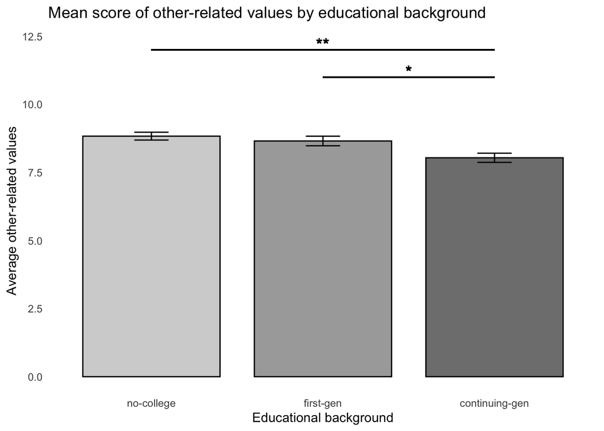

```r
# Ensure 'first_gen_college' is a factor
df_PA2$first_gen_college <- as.factor(df_PA2$first_gen_college)
# plot other-related value by educational background
ggplot(df_PA2, aes(x = first_gen_college, y = value_other_T1,
                   fill = first_gen_college)) +
  geom_bar(stat = "summary", fun = "mean", position = position_dodge(width = 0.9),
           color = "black", width = 0.8) +  # Bars without space between them
  geom_errorbar(stat = "summary", fun.data = mean_se, width = 0.2,
                position = position_dodge(width = 0.9)) +
  labs(title = "Mean score of other-related values by educational background",
       x = "First-gen status",
       y = "Average other-related values") +
  theme_minimal() +
  scale_x_discrete(name = "Educational background",
                   labels = c("no-college", "first-gen", "continuing-gen")) +
  scale_fill_manual(values = c("0" = "white",     # no college
                               "1" = "lightgray", # first-gen
                               "2" = "darkgray")) + # continuing-gen
  theme(legend.position = "none",
        panel.grid = element_blank()) +  # Remove grid lines

  # Add significance lines and star annotations
  geom_segment(aes(x = 2, xend = 3, y = max(df_PA2$value_other_T1) + 1, yend = max(df_PA2$value_other_T1) + 1)) +  # Line for first-gen vs. continuing-gen (one star)
  geom_text(aes(x = 2.5, y = max(df_PA2$value_other_T1) + 1.2, label = "*"), size = 5) +  # One star for first-gen vs. continuing-gen (p < 0.05)

  geom_segment(aes(x = 1, xend = 3, y = max(df_PA2$value_other_T1) + 2, yend = max(df_PA2$value_other_T1) + 2)) +  # Line for no-college vs. continuing-gen (two stars)
  geom_text(aes(x = 2, y = max(df_PA2$value_other_T1) + 2.2, label = "**"), size = 5)   # Two stars for no-college vs. continuing-gen (p < 0.01)
```

### 4.1.2 First-gens status and self-related values

According to the results of ANOVA and linear regression (N=220), regarding the means of self-related values, there’s no significant difference between the three groups. The ANOVA results indicated no significant effect of group, $F(2, 217) = 1.24, p = 0.29, η² = 0.01$.  
The bar plot showed that both first-gen and continuing-gen groups attributed slightly greater importance to self-related values than no-college group.

```r
# Run ANOVA
anova_result_self <- aov(value_self_T1 ~ as.factor(first_gen_college), data = df_PA2)
summary(anova_result_self)
```

```
##                               Df Sum Sq Mean Sq F value Pr(>F)
## as.factor(first_gen_college)   2   10.9   5.461   1.238  0.292
## Residuals                    217  957.2   4.411
```

```r
# Calculate effect size (eta squared)
eta_squared_value <- car::Anova(anova_result_self, type="II")$"Sum Sq"[1] / sum(car::Anova(anova_result_self, type="II")$"Sum Sq")
eta_squared_value
```

```
## [1] 0.01128171
```

```r
# Run linear regression
lm_result_self <- lm(value_self_T1 ~ as.factor(first_gen_college), data = df_PA2)
summary(lm_result_self)
```

```
##
## Call:
## lm(formula = value_self_T1 ~ as.factor(first_gen_college), data = df_PA2)
##
## Residuals:
##     Min      1Q  Median      3Q     Max
## -4.5904 -1.2570 -0.2523  1.4144  5.9048
##
## Coefficients:
##                               Estimate Std. Error t value Pr(>|t|)
## (Intercept)                     4.0952     0.2646  15.476   <2e-16 ***
## as.factor(first_gen_college)2   0.4903     0.3600   1.362    0.175
## as.factor(first_gen_college)3   0.4951     0.3510   1.411    0.160
## ---
## Signif. codes:  0 '***' 0.001 '**' 0.01 '*' 0.05 '.' 0.1 ' ' 1
##
## Residual standard error: 2.1 on 217 degrees of freedom
## Multiple R-squared:  0.01128,    Adjusted R-squared:  0.002169
## F-statistic: 1.238 on 2 and 217 DF,  p-value: 0.292
```

```r
# Run linear regression with the desired reference level specified in the formula
lm_result_self_relevel <- lm(value_self_T1 ~ relevel(as.factor(first_gen_college), ref = "2"), data = df_PA2)
summary(lm_result_self_relevel)
```

```
##
## Call:
## lm(formula = value_self_T1 ~ relevel(as.factor(first_gen_college),
##     ref = "2"), data = df_PA2)
##
## Residuals:
##     Min      1Q  Median      3Q     Max
## -4.5904 -1.2570 -0.2523  1.4144  5.9048
##
## Coefficients:
##                                                    Estimate Std. Error t value
## (Intercept)                                        4.585586   0.244154  18.782
## relevel(as.factor(first_gen_college), ref = "2")1 -0.490347   0.360043  -1.362
## relevel(as.factor(first_gen_college), ref = "2")3  0.004776   0.335795   0.014
##                                                   Pr(>|t|)
## (Intercept)                                         <2e-16 ***
## relevel(as.factor(first_gen_college), ref = "2")1    0.175
## relevel(as.factor(first_gen_college), ref = "2")3    0.989
## ---
## Signif. codes:  0 '***' 0.001 '**' 0.01 '*' 0.05 '.' 0.1 ' ' 1
##
## Residual standard error: 2.1 on 217 degrees of freedom
## Multiple R-squared:  0.01128,    Adjusted R-squared:  0.002169
## F-statistic: 1.238 on 2 and 217 DF,  p-value: 0.292
```

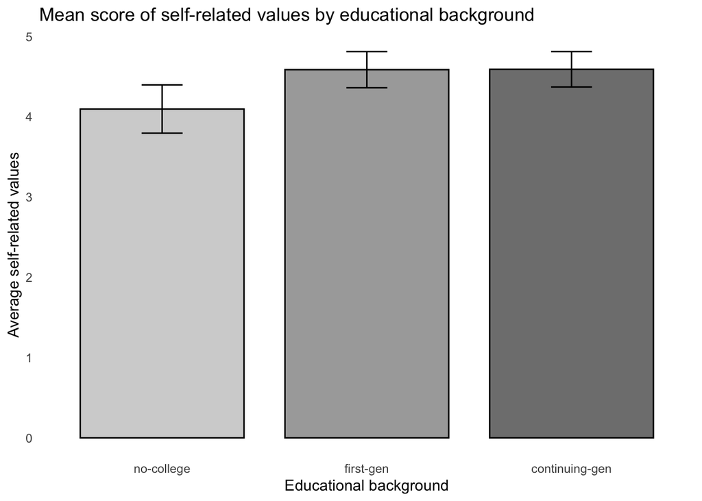

```r
# plot self-related value by educational background
ggplot(df_PA2, aes(x = first_gen_college, y = value_self_T1,
                   fill = first_gen_college)) +
  geom_bar(stat = "summary", fun = "mean", position = position_dodge(width = 0.9),
           color = "black", width = 0.8) +  # Bars without space between them
  geom_errorbar(stat = "summary", fun.data = mean_se, width = 0.2,
                position = position_dodge(width = 0.9)) +
  labs(title = "Mean score of self-related values by educational background",
       x = "First-gen status",
       y = "Average self-related values") +
  theme_minimal() +
  scale_x_discrete(name = "Educational background",
                   labels = c("no-college", "first-gen", "continuing-gen")) +
  scale_fill_manual(values = c("0" = "white",     # no college
                               "1" = "lightgray", # first-gen
                               "2" = "darkgray")) + # continuing-gen
  theme(legend.position = "none",
        panel.grid = element_blank())  # Remove grid lines
```

## 4.2 SES and values

We are interested in whether the subjective measures of SES predicted participants’ pursuit of other-related (or self-related) values.

### 4.2.1 SES and other-related values

The results of ANOVA and linear regression (N=220) indicated that the pursuit of other-related values doesn’t demonstrate any significant difference across different levels of SES. The relationship between `SES` and `value_other_T1` was not significant, ( $\beta$ = -0.03, t = -0.52, p = 0.61 ).

```r
summary(aov(value_other_T1 ~ as.factor(SES), df_PA2))
```

```
##                 Df Sum Sq Mean Sq F value Pr(>F)
## as.factor(SES)   9   10.9   1.209   0.554  0.833
## Residuals      210  458.2   2.182
```

```r
summary(lm(value_other_T1 ~ SES, df_PA2))
```

```
##
## Call:
## lm(formula = value_other_T1 ~ SES, data = df_PA2)
##
## Residuals:
##     Min      1Q  Median      3Q     Max
## -7.1015 -0.8210  0.4596  1.1856  1.6443
##
## Coefficients:
##             Estimate Std. Error t value Pr(>|t|)
## (Intercept)  8.61956    0.30274  28.472   <2e-16 ***
## SES         -0.02638    0.05089  -0.518    0.605
## ---
## Signif. codes:  0 '***' 0.001 '**' 0.01 '*' 0.05 '.' 0.1 ' ' 1
##
## Residual standard error: 1.466 on 218 degrees of freedom
## Multiple R-squared:  0.001231,   Adjusted R-squared:  -0.00335
## F-statistic: 0.2687 on 1 and 218 DF,  p-value: 0.6047
```

### 4.2.2 SES and self-related values

The results of ANOVA and linear regression (N=220) indicated that participants of higher SES attributed significantly greater importance to self-related values, ( $\beta$ = 0.25, t = 3.55, p < 0.001 ).  
The bar plot demonstrated the overall positive relationship between SES and pursuits of self-related values.

```r
summary(aov(value_self_T1 ~ as.factor(SES), df_PA2))
```

```
##                 Df Sum Sq Mean Sq F value  Pr(>F)
## as.factor(SES)   9   96.5  10.717   2.582 0.00769 **
## Residuals      210  871.7   4.151
## ---
## Signif. codes:  0 '***' 0.001 '**' 0.01 '*' 0.05 '.' 0.1 ' ' 1
```

```r
summary(lm(value_self_T1 ~ SES, df_PA2))
```

```
##
## Call:
## lm(formula = value_self_T1 ~ SES, data = df_PA2)
##
## Residuals:
##     Min      1Q  Median      3Q     Max
## -4.5422 -1.4006 -0.0017  1.3769  5.7102
##
## Coefficients:
##             Estimate Std. Error t value Pr(>|t|)
## (Intercept)  3.02766    0.42317   7.155 1.26e-11 ***
## SES          0.25242    0.07114   3.548 0.000475 ***
## ---
## Signif. codes:  0 '***' 0.001 '**' 0.01 '*' 0.05 '.' 0.1 ' ' 1
##
## Residual standard error: 2.049 on 218 degrees of freedom
## Multiple R-squared:  0.0546, Adjusted R-squared:  0.05027
## F-statistic: 12.59 on 1 and 218 DF,  p-value: 0.0004746
```

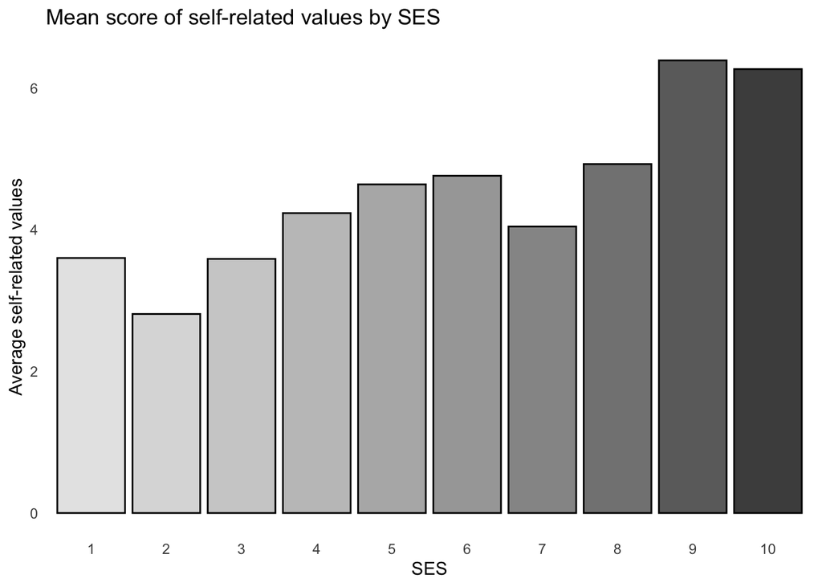

```r
ggplot(df_PA2, aes(x = as.factor(SES), y = value_self_T1, fill = as.factor(SES))) +
  geom_bar(stat = "summary", fun = "mean", position = "dodge", color = "black") +  # Add black borders
  labs(title = "Mean score of self-related values by SES",
       x = "SES",
       y = "Average self-related values") +
  theme_minimal() +
  scale_fill_manual(values = rev(gray.colors(10))) +  # Reverse shades of gray
  theme(legend.position = "none",
        panel.grid = element_blank())  # Remove grid lines
```

## 4.3 Values with both first-gen status and SES

The analyses of variance indicated that first-generation status was the only predictor of other-related values at T1, and that SES was the only predictor of self-related values at T1.

### 4.3.1 Other-related values with both first-gen status and SES

The analysis of variance and regression results revealed a significant main effect of first-gen college status on value_other at T1, F(2, 208) = 6.32, p = .002, indicating that first-gen status was the primary variable driving the effect. In contrast, SES did not have a significant impact, F(9, 208) = 0.52, p = 0.858.

```r
other_model <- lm(value_other_T1 ~ as.factor(first_gen_college) + as.factor(SES), data = df_PA2)
summary(other_model)
```

```
##
## Call:
## lm(formula = value_other_T1 ~ as.factor(first_gen_college) +
##     as.factor(SES), data = df_PA2)
##
## Residuals:
##     Min      1Q  Median      3Q     Max
## -7.0118 -0.8098  0.3036  1.0259  2.2520
##
## Coefficients:
##                               Estimate Std. Error t value Pr(>|t|)
## (Intercept)                    8.78933    0.66971  13.124  < 2e-16 ***
## as.factor(first_gen_college)2 -0.20552    0.25068  -0.820  0.41324
## as.factor(first_gen_college)3 -0.80259    0.24496  -3.276  0.00123 **
## as.factor(SES)2                0.02367    0.84621   0.028  0.97771
## as.factor(SES)3                0.15967    0.72007   0.222  0.82473
## as.factor(SES)4                0.06882    0.69777   0.099  0.92152
## as.factor(SES)5                0.41030    0.69217   0.593  0.55398
## as.factor(SES)6               -0.07492    0.68073  -0.110  0.91247
## as.factor(SES)7               -0.23872    0.69023  -0.346  0.72980
## as.factor(SES)8                0.08495    0.70248   0.121  0.90387
## as.factor(SES)9                0.40135    0.87645   0.458  0.64749
## as.factor(SES)10              -0.18770    0.91772  -0.205  0.83814
## ---
## Signif. codes:  0 '***' 0.001 '**' 0.01 '*' 0.05 '.' 0.1 ' ' 1
##
## Residual standard error: 1.443 on 208 degrees of freedom
## Multiple R-squared:  0.07692,    Adjusted R-squared:  0.02811
## F-statistic: 1.576 on 11 and 208 DF,  p-value: 0.1077
```

```r
# Print ANOVA table to assess whether each significantly contributes to explaining variability in the other-related values
anova(other_model)
```

```
## Analysis of Variance Table
##
## Response: value_other_T1
##                               Df Sum Sq Mean Sq F value   Pr(>F)
## as.factor(first_gen_college)   2  26.30 13.1506  6.3177 0.002169 **
## as.factor(SES)                 9   9.78  1.0866  0.5220 0.857697
## Residuals                    208 432.96  2.0815
## ---
## Signif. codes:  0 '***' 0.001 '**' 0.01 '*' 0.05 '.' 0.1 ' ' 1
```

### 4.3.2 Self-related values with both first-gen status and SES

The analysis of variance and regression results suggested that SES was the primary variable driving the effect on value_self at T1. The ANOVA table showed a significant effect of SES on value_self, $F(9, 208) = 2.79, p < 0.01$, while first-gen college status did not have a significant effect, F(2, 208) = 1.33, p = 0.267. In the regression model, specific levels of SES, SES9 ( $\beta$ = 2.97, t = 2.41, p < 0.05 ) and SES10 ( $\beta$ = 2.91, t = 2.26, p < 0.05 ), were significantly associated with value_self at T1. These results indicated that differences in SES were more influential in predicting value_self at T1 than first-gen college status.

```r
self_model <- lm(value_self_T1 ~ as.factor(first_gen_college) + as.factor(SES), data = df_PA2)
summary(self_model)
```

```
##
## Call:
## lm(formula = value_self_T1 ~ as.factor(first_gen_college) + as.factor(SES),
##     data = df_PA2)
##
## Residuals:
##     Min      1Q  Median      3Q     Max
## -4.3074 -1.4341 -0.0272  1.4003  5.8438
##
## Coefficients:
##                               Estimate Std. Error t value Pr(>|t|)
## (Intercept)                    3.10509    0.94056   3.301  0.00113 **
## as.factor(first_gen_college)2  0.66785    0.35206   1.897  0.05921 .
## as.factor(first_gen_college)3  0.60224    0.34403   1.751  0.08150 .
## as.factor(SES)2               -0.83989    1.18844  -0.707  0.48054
## as.factor(SES)3                0.02705    1.01128   0.027  0.97869
## as.factor(SES)4                0.68918    0.97997   0.703  0.48267
## as.factor(SES)5                1.05114    0.97210   1.081  0.28081
## as.factor(SES)6                1.20235    0.95604   1.258  0.20993
## as.factor(SES)7                0.50821    0.96938   0.524  0.60065
## as.factor(SES)8                1.33785    0.98659   1.356  0.17656
## as.factor(SES)9                2.97175    1.23091   2.414  0.01663 *
## as.factor(SES)10               2.90756    1.28887   2.256  0.02512 *
## ---
## Signif. codes:  0 '***' 0.001 '**' 0.01 '*' 0.05 '.' 0.1 ' ' 1
##
## Residual standard error: 2.026 on 208 degrees of freedom
## Multiple R-squared:  0.1179, Adjusted R-squared:  0.07129
## F-statistic: 2.528 on 11 and 208 DF,  p-value: 0.005172
```

```r
# Print ANOVA table to assess overall model significance
anova(self_model)
```

```
## Analysis of Variance Table
##
## Response: value_self_T1
##                               Df Sum Sq Mean Sq F value   Pr(>F)
## as.factor(first_gen_college)   2  10.92  5.4612  1.3302 0.266669
## as.factor(SES)                 9 103.26 11.4737  2.7946 0.004089 **
## Residuals                    208 853.97  4.1056
## ---
## Signif. codes:  0 '***' 0.001 '**' 0.01 '*' 0.05 '.' 0.1 ' ' 1
```

# 5 Word cloud (*For EPA submission, only focused on three groups’ word clouds)

actual group size (no-college, first-gen, continuing-gen)

```r
# prepare the data frames containing writings from no-college, first-gen, and continuing-gen
# no-college
affirm_nocollege <- df_PA2 %>%
  filter(
    first_gen_college == 1 &
    condition == "A"
  )
#nrow(affirm_nocollege)
sum(affirm_nocollege$writing != "")
```

```
## [1] 17
```

```r
# first-gen
affirm_firstgen <- df_PA2 %>%
  filter(
    first_gen_college == 2 &
    condition == "A"
  )
#nrow(affirm_firstgen)
sum(affirm_firstgen$writing != "")
```

```
## [1] 30
```

```r
# continuing-gen
affirm_continuinggen <- df_PA2 %>%
  filter(
    first_gen_college == 3 &
    condition == "A"
  )
#nrow(affirm_continuinggen)
sum(affirm_continuinggen$writing != "")
```

```
## [1] 33
```

```r
# Not used for EPA submission
# Word cloud preparation for the Affirmation condition where they ranked other-related values as most important
# Filter the dataset to prepare the subsets of the three groups
affirm_other_df <- df_PA2 %>%
  filter(
    condition == "A" &
      (Value_T1_rank_Compassion_Kindness == 1 |
         Value_T1_rank_Family_Friends == 1 |
         Value_T1_rank_Spirituality == 1)
  )

# no-college
affirm_other_df_1 <- df_PA2 %>%
  filter(
    first_gen_college == 1 &
    condition == "A" &
      (Value_T1_rank_Compassion_Kindness == 1 |
         Value_T1_rank_Family_Friends == 1 |
         Value_T1_rank_Spirituality == 1)
  )
#nrow(affirm_other_df_1)

# first-gen
affirm_other_df_2 <- df_PA2 %>%
  filter(
    first_gen_college == 2 &
    condition == "A" &
      (Value_T1_rank_Compassion_Kindness == 1 |
         Value_T1_rank_Family_Friends == 1 |
         Value_T1_rank_Spirituality == 1)
  )
#nrow(affirm_other_df_2)

# continuing-gen
affirm_other_df_3 <- df_PA2 %>%
  filter(
    first_gen_college == 3 &
    condition == "A" &
      (Value_T1_rank_Compassion_Kindness == 1 |
         Value_T1_rank_Family_Friends == 1 |
         Value_T1_rank_Spirituality == 1)
  )
#nrow(affirm_other_df_3)
```

```r
# Not used for EPA submission
# Word cloud preparation for Affirmation condition where they ranked self-related values highest.
# Filter the dataset to prepare the subset for the three groups
affirm_self_df <- df_PA2 %>%
  filter(
    condition == "A" &
      (Value_T1_rank_Power_Status == 1 |
         Value_T1_rank_Wealth == 1 |
         Value_T1_rank_Fame == 1)
  )

affirm_self_df_1 <- df_PA2 %>%
  filter(
    first_gen_college == 1 &
    condition == "A" &
      (Value_T1_rank_Power_Status == 1 |
         Value_T1_rank_Wealth == 1 |
         Value_T1_rank_Fame == 1)
  )
#nrow(affirm_self_df_1)

affirm_self_df_2 <- df_PA2 %>%
  filter(
    first_gen_college == 2 &
    condition == "A" &
      (Value_T1_rank_Power_Status == 1 |
         Value_T1_rank_Wealth == 1 |
         Value_T1_rank_Fame == 1)
  )
#nrow(affirm_self_df_2)

affirm_self_df_3 <- df_PA2 %>%
  filter(
    first_gen_college == 3 &
    condition == "A" &
      (Value_T1_rank_Power_Status == 1 |
         Value_T1_rank_Wealth == 1 |
         Value_T1_rank_Fame == 1)
  )
#nrow(affirm_self_df_3)
```

Word clouds

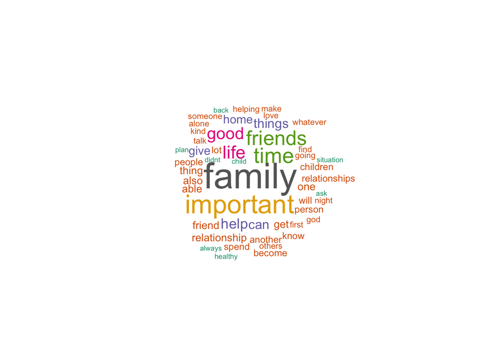

```r
# Step 1: Function to generate word clouds for a list of data frames
generate_wordclouds <- function(data_frames) {
  for (i in seq_along(data_frames)) {
    # Step 2: Convert the 'writing' column to a character vector
    text_data <- as.character(data_frames[[i]]$writing)

    # Step 3: Create a corpus from the text data
    corpus <- Corpus(VectorSource(text_data))

    # Step 4: Clean the text data (remove punctuation, stopwords, etc.)
    corpus_clean <- tm_map(corpus, content_transformer(tolower))
    corpus_clean <- tm_map(corpus_clean, removePunctuation)
    corpus_clean <- tm_map(corpus_clean, removeNumbers)
    corpus_clean <- tm_map(corpus_clean, removeWords, stopwords("en"))
    corpus_clean <- tm_map(corpus_clean, stripWhitespace)

    # Step 5: Create a Document-Term Matrix (DTM)
    dtm <- TermDocumentMatrix(corpus_clean)

    # Step 6: Convert the DTM to a matrix and check word frequencies
    matrix <- as.matrix(dtm)
    word_freq <- sort(rowSums(matrix), decreasing = TRUE)

    # If needed, print the word frequencies to ensure it's not empty
    #print(paste("Word frequencies for affirm_self_df_", i, ":", sep = ""))
    #print(word_freq)

    # Step 7: Check if word_freq is empty
    if (length(word_freq) == 0) {
      print(paste("No words found in the corpus after cleaning for affirm_self_df_", i, ".", sep = ""))
    } else {
      # Step 8: Generate the Word Cloud if words are present
      set.seed(1234)  # For reproducibility
      wordcloud(
        words = names(word_freq),
        freq = word_freq,
        min.freq = 1,          # Adjust to a lower value if needed
        max.words = 50,       # Max number of words to include
        random.order = FALSE,  # Words with higher frequency are centered
        rot.per = 0,  # Set rotation to 0 for all words horizontal
        scale = c(3, 0.3),
        colors = brewer.pal(8, "Dark2")  # Color palette for the words
      )
    }
  }
}

# Generate self-related word clouds for all three data frames
# generate_wordclouds(list(affirm_self_df_1, affirm_self_df_2, affirm_self_df_3))

# Generate other-related word clouds for all three data frames
# generate_wordclouds(list(affirm_other_df_1, affirm_other_df_2, affirm_other_df_3))

# Generate word clouds for three groups
generate_wordclouds(list(affirm_nocollege))
```

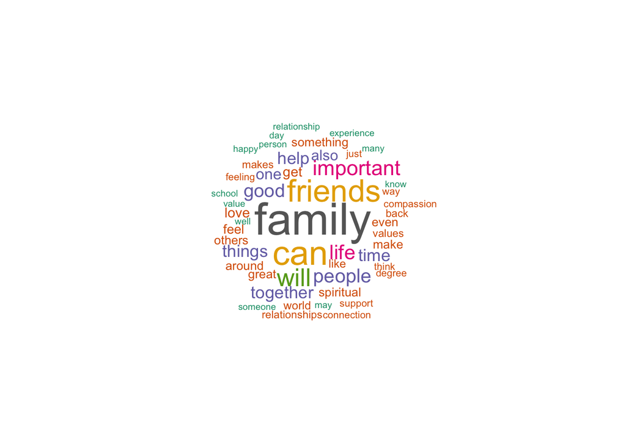

```r
generate_wordclouds(list(affirm_firstgen))
```

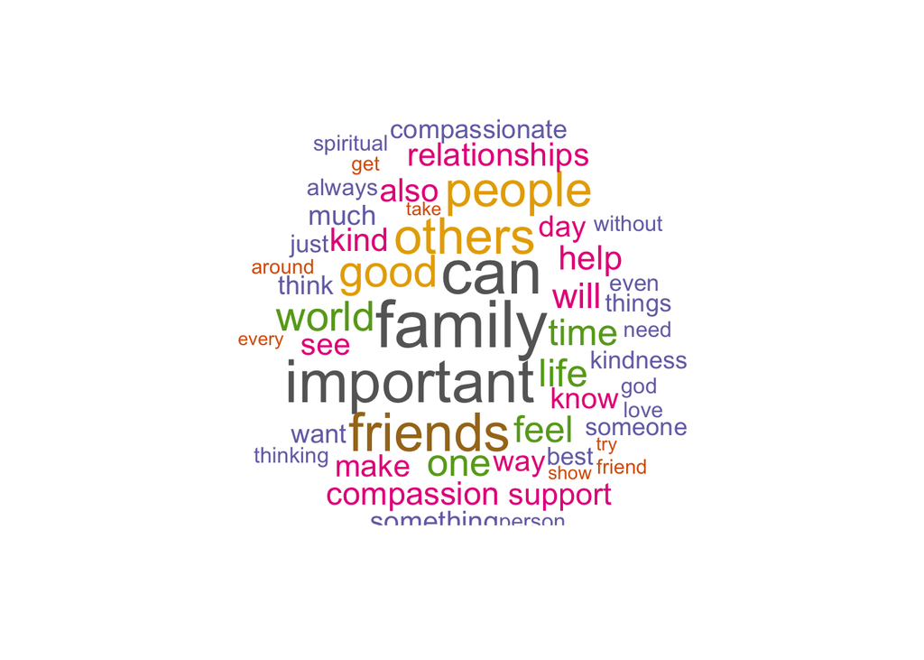

```r
generate_wordclouds(list(affirm_continuinggen))
```

# 6 LIWC (For publication?)

```r
# LIWC Preparation (take affirmation writing as a dataset to feed into LIWC)
# lm(Value_self_transcendent ~ linguistic_feature + Value_self_enhancing + first_gen_college, data = affirm_df)
```